# Gambia model parameters

Nora Schmit

13 June 2019

```
## here() starts at C:/Users/Nora Schmit/Documents/Model development/hbvmodel
```

## Parameter definitions

| Parameter name | Parameter definition | Shevanthi Ethiopia value | Margaret Ethiopia fit | Notes | Parameter type |
| --- | --- | --- | --- | --- | --- |
| b1 | Horizontal transmission rate among children (age 1-5 years). Note <1 year olds are not involved in horizontal transmission. | NA | NA |  | Transmission |
| b2 | Horizontal transmission rate among juveniles (age 6-15 years) and between children and juveniles | NA | NA |  | Transmission |
| b3 | Horizontal transmission rate among adults (age 16-100 years) and between adults and juveniles. Note there is no mixing between adults and children. | NA | NA |  | Transmission |
| alpha | Relative infectiousness of HBeAg-positives compared to HBeAg-negatives for horizontal transmission | 15.0000 | 15.0000000 |  | Transmission |
| mtct_prob_e | Mother-to-child transmission risk from HBeAg-positive mother | 0.9000 | 0.9000000 |  | Transmission |
| mtct_prob_s | Mother-to-child transmission risk from HBeAg-negative mother | 0.2000 | 0.3681000 |  | Transmission |
| p_chronic_function_r | Parameter r of exponential decay function for age-specific risk of becoming a chronic carrier after acute infection | 0.6500 | 0.6500000 | Edmunds value | Natural history |
| p_chronic_function_s | Parameter s of exponential decay function for age-specific risk of becoming a chronic carrier after acute infection | 0.4600 | 0.4600000 | Edmunds value | Natural history |
| pr_it_ir | Multiplier on progression rate from Immune tolerant to Immune reactive stage | 0.1000 | 0.1000000 |  | Natural history |
| pr_ir_ic | Multiplier on progression rate from Immune reactive to Inactive carrier stage (HBeAg loss) | 0.0500 | 0.0500000 |  | Natural history |
| eag_prog_function_intercept | Intercept of exponential decay function for age-specific progression through the HBeAg-positive compartments (Immune tolerant and Immune reactive) | 2.0374 | 9.5000000 |  | Natural history |
| eag_prog_function_rate | Rate parameter of exponential decay function for age-specific progression through the HBeAg-positive compartments (Immune tolerant and Immune reactive) | 0.0010 | 0.1281000 |  | Natural history |
| pr_ir_enchb | Annual progression rate from Immune reactive to HBeAg-negative chronic hepatitis B (HBeAg loss) | 0.0050 | 0.0050000 |  | Natural history |
| pr_ir_enchb_age_threshold | Age threshold for progression from Immune reactive to HBeAg-negative chronic hepatitis B (rate = 0 below this age) | NA | 20.0000000 |  | Natural history |
| pr_ir_cc | Annual progression rate from Immune reactive to Compensated cirrhosis | 0.0280 | 0.0280000 | Added after publication | Natural history |
| pr_ir_cc_age_threshold | Age threshold for progression from Immune reactive to Compensated cirrhosis (rate = 0 below this age) | NA | 20.0000000 |  | Natural history |
| pr_ic_enchb | Annual progression rate from Inactive carrier to HBeAg-negative chronic hepatitis B (reactivation) | 0.0100 | 0.0100000 |  | Natural history |
| sag_loss_0to9 | Annual rate of HBsAg loss in 0-9 year olds (progression rate from Inactive carrier to Immune) | 0.0100 | 0.0100000 | Shimakawa age-specific values | Natural history |
| sag_loss_10to19 | Annual rate of HBsAg loss in 10-19 year olds (progression rate from Inactive carrier to Immune) | 0.0100 | 0.0100000 | Shimakawa age-specific values | Natural history |
| sag_loss_20to29 | Annual rate of HBsAg loss in 20-29 year olds (progression rate from Inactive carrier to Immune) | 0.0100 | 0.0100000 | Shimakawa age-specific values | Natural history |
| sag_loss_30to39 | Annual rate of HBsAg loss in 30-39 year olds (progression rate from Inactive carrier to Immune) | 0.0100 | 0.0100000 | Shimakawa age-specific values | Natural history |
| sag_loss_40to49 | Annual rate of HBsAg loss in 40-49 year olds (progression rate from Inactive carrier to Immune) | 0.0100 | 0.0100000 | Shimakawa age-specific values | Natural history |
| sag_loss_50to70 | Annual rate of HBsAg loss in 50+ year olds (progression rate from Inactive carrier to Immune) | 0.0100 | 0.0100000 | Shimakawa age-specific values | Natural history |
| pr_enchb_cc | Annual progression rate from HBeAg-negative chronic hepatitis B to Compensated cirrhosis | 0.0400 | 0.0400000 |  | Natural history |
| cirrhosis_age_threshold | Age threshold for progression from HBeAg-negative chronic hepatitis B to Compensated cirrhosis (rate = 0 below this age) | NA | 25.0000000 |  | Natural history |
| cirrhosis_prog_male_cofactor | Multiplier on progression rate to from HBeAg-negative chronic hepatitis B to Compensated cirrhosis for men | NA | 12.3200000 |  | Natural history |
| dccrate | Annual progression rate from Compensatd cirrhosis to Decompensated cirrhosis | 0.0400 | 0.0400000 |  | Natural history |
| cancer_prog_coefficient | Coefficient of quadratic shift function for age-specific progression rates to HCC | NA | 0.0000405 |  | Natural history: progression to HCC |
| cancer_age_threshold | Age threshold for progression to HCC (from any carrier compartment other than DCC) (rate = 0 below this age) | NA | 10.0000000 |  | Natural history: progression to HCC |
| cancer_prog_male_cofactor | Multiplier on progression rates to HCC (from any carrier compartment other than DCC) for men | 5.0000 | 5.2075000 |  | Natural history: progression to HCC |
| hccr_it | Multiplier on progression rate to HCC from Immune tolerant | 1.0000 | 1.0000000 |  | Natural history: progression to HCC |
| hccr_ir | Multiplier on progression rate to HCC from Immune reactive | 2.0000 | 2.0000000 |  | Natural history: progression to HCC |
| hccr_ic | Multiplier on progression rate to HCC from Inactive carrier | 0.5000 | 0.5000000 |  | Natural history: progression to HCC |
| hccr_enchb | Multiplier on progression rate to HCC from HBeAg-negative chronic hepatitis B stage | 2.0000 | 2.0000000 |  | Natural history: progression to HCC |
| hccr_cc | Multiplier on progression rate to HCC from Compensated cirrhosis stage | 13.0000 | 13.0000000 |  | Natural history: progression to HCC |
| hccr_dcc | Annual progression rate from Decompensated cirrhosis to HCC | 0.0400 | 0.0400000 |  | Natural history: progression to HCC |
| mu_cc | Annual rate of additional mortality from Compensated cirrhosis | 0.0390 | 0.0390000 |  | HBV-related mortality rates |
| mu_dcc | Annual rate of additional mortality from Deompensated cirrhosis | 0.3140 | 0.3140000 |  | HBV-related mortality rates |
| mu_hcc | Annual rate of additional mortality from HCC | 0.5000 | 0.5000000 |  | HBV-related mortality rates |
| vacc_eff | Infant vaccine efficacy against chronic carriage | 0.9500 | 0.9500000 |  | Intervention |

## Age-specific progression functions

**Risk of becoming a chronic carrier after acute infection (Edmunds function):**

For ages < 0.5 years: risk = 0.89  
For ages >= 0.5 years: risk = exp(-p_chronic_function_r * ages^p_chronic_function_s)

**Progressions through HBeAg-positive compartments:**

Rate = Multiplier * eag_prog_function_intercept * exp(-eag_prog_function_rate * ages)

*Multipliers: pr_it_ir for progression from Immune tolerant to Immune reactive, pr_ir_ic for progression from Immune reactive to Inactive carrier*

**Progressions to HCC:**

In women and men aged < cancer_age_threshold: rate = 0  
In women aged > cancer_age_threshold: rate = Multiplier * (cancer_prog_coefficient * (ages - cancer_age_threshold))^2  
In men aged > cancer_age_threshold: rate = cancer_prog_male_cofactor * age-specific rate in women

Multipliers: pr_hccr_it from Immune tolerant, pr_hccr_ir from Immune reactive, pr_hccr_ic from Inactive carrier, pr_hccr_enchb from HBeAg-negative chronic hepatitis B, pr_hccr_cc from Compensated cirrhosis  
Note progression from Decompensated cirrhosis to HCC (hccr_dcc) is not age- or sex-dependent.

**Progression from Immune reactive to HBeAg-negative chronic hepatitis B:**

For ages < pr_ir_enchb_age_threshold: rate = 0  
For ages > pr_ir_enchb_age_threshold: rate = pr_ir_enchb

**Progression from immune reactive to Compensated cirrhosis:**

For ages < pr_ir_cc_age_threshold: rate = 0  
For ages > pr_ir_cc_age_threshold: rate = pr_ir_cc

**Progression from HBeAg-negative chronic hepatitis B to Compensated cirrhosis:**

In women and men aged < cirrhosis_age_threshold: rate = 0  
In women aged > cirrhosis_age_threshold: rate = pr_enchb_cc  
In men aged > cirrhosis_age_threshold: rate = cirrhosis_prog_male_cofactor * age-specific rate in women

```
## $b1
## [1] 0.12
##
## $b2
## [1] 0.04
##
## $b3
## [1] 0.01
##
## $alpha
## [1] 7
##
## $mtct_prob_e
## [1] 0.6
##
## $mtct_prob_s
## [1] 0.05
##
## $p_chronic_function_r
## [1] 0.65
##
## $p_chronic_function_s
## [1] 0.46
##
## $pr_it_ir
## [1] 0.1
##
## $pr_ir_ic
## [1] 1
##
## $eag_prog_function_intercept
## [1] 1
##
## $eag_prog_function_rate
## [1] 0
##
## $pr_ir_enchb
## [1] 0.005
##
## $pr_ir_enchb_age_threshold
```

[output cut: 82 more lines]

```
##
## $sim_starttime
## [1] 1880
##
## $apply_vacc
## [1] 1
##
## $births_on
## [1] 1
##
## $migration_on
## [1] 1
##
## $mortality_on
## [1] 1
```

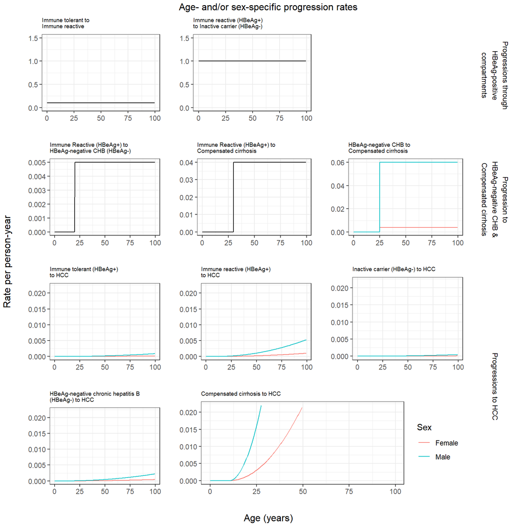